# Answer to Q2

### Answer to Q2(1)

The rate of change of the concentration of each species can be described using the law of mass action. The four equations for the rate of change of the four species, $E$, $S$, $ES$, and $P$, are as follows:

$$\cfrac{d[E]}{dt} = -k_{1}[E][S] + k_{2}[ES] + k_{3}[ES]\\\\
\cfrac{d[S]}{dt} = -k_{1}[E][S] + k_{2}[ES]\\\\
\cfrac{d[ES]}{dt} = k_{1}[E][S] - k_{2}[ES] - k_{3}[ES]\\\\
\cfrac{d[P]}{dt} = k_{3}[ES]$$

where $[E]$, $[S]$, $[ES]$, and $[P]$ represent the concentrations of the enzymes $E$, substrate $S$, intermediate species $ES$, and product $P$, respectively. $\cfrac{d[E]}{dt}$, $\cfrac{d[S]}{dt}$, $\cfrac{d[ES]}{dt}$, $\cfrac{d[P]}{dt}$ represent the rate of change of concentration of each species and $k_{1}$, $k_{2}$, $k_{3}$ are the forward rate, reverse rate and breakdown rate of the intermediate species into product, respectively.

### Answer to Q2(2)

```r
k1 <- 100
k2 <- 600
k3 <- 150
dt <- 0.001
num_step <- 1000
E <- c()
S <- c()
ES <- c()
P <- c()
E[1] <- 1
S[1] <- 10
ES[1] <- 0
P[1] <- 0

deriv <- function(E, S, ES, P) { # calculate the derivatives
  dEdt <- -k1*E*S + k2*ES + k3*ES
  dSdt <- -k1*E*S + k2*ES
  dESdt <- k1*E*S - k2*ES - k3*ES
  dPdt <- k3*ES
  return(c(dEdt, dSdt, dESdt, dPdt))
}

# fourth-order Runge-Kutta method
for (i in 2:num_step) {
  E1 <- E[i-1]
  S1 <- S[i-1]
  ES1 <- ES[i-1]
  P1 <- P[i-1]
  h1 <- deriv(E1, S1, ES1, P1)
  E2 <- E1 + 0.5*dt*h1[1]
  S2 <- S1 + 0.5*dt*h1[2]
  ES2 <- ES1 + 0.5*dt*h1[3]
  P2 <- P1 + 0.5*dt*h1[4]
  h2 <- deriv(E2, S2, ES2, P2)
  E3 <- E1 + 0.5*dt*h2[1]
  S3 <- S1 + 0.5*dt*h2[2]
  ES3 <- ES1 + 0.5*dt*h2[3]
  P3 <- P1 + 0.5*dt*h2[4]
  h3 <- deriv(E3, S3, ES3, P3)
  E4 <- E1 + dt*h3[1]
  S4 <- S1 + dt*h3[2]
  ES4 <- ES1 + dt*h3[3]
  P4 <- P1 + dt*h3[4]
  h4 <- deriv(E4, S4, ES4, P4)
  E[i] <- E1 + (h1[1]+2*h2[1]+2*h3[1]+h4[1])*dt/6
  S[i] <- S1 + (h1[2]+2*h2[2]+2*h3[2]+h4[2])*dt/6
  ES[i] <- ES1 + (h1[3]+2*h2[3]+2*h3[3]+h4[3])*dt/6
  P[i] <- P1 + (h1[4]+2*h2[4]+2*h3[4]+h4[4])*dt/6
}
Final_E<-E[num_step]
Final_S<-S[num_step]
Final_ES<-ES[num_step]
Final_P<-P[num_step]
Final_E
```

```
## [1] 0.9999999
```

```r
Final_S
```

```
## [1] 4.156714e-07
```

```r
Final_ES
```

```
## [1] 5.678799e-08
```

```r
Final_P
```

```
## [1] 10
```

### Answer to Q2(3)

When the system enters the steady state, we will have $\cfrac{d[S]}{dt} = -k_{1}[E][S] + k_{2}[ES] = 0$ and then it becomes $k_{1}[E][S] = k_{2}[ES]$. By referring to Michaelis–Menten kinetics (Johnson and Goody, 2011), we set $[E]_{0} = [E] + [ES]$ as the initial enzyme concentration and then $k_{1}[E][S] = k_{1}([E]_{0} - [ES])[S] = k_{2}[ES]$. Finally, we will have the following equation:
$$V = \cfrac{d[P]}{dt} = k_{3}[ES] = k_{3}[E]_{0}\cfrac{k_{1}[S]}{k_{2} + k_{1}[S]} = V_{max}\cfrac{[S]}{K_{d} + [S]}$$
where $V_{max} = k_{3}[E]_{0}$ and $K_{d} = \cfrac{k_{2}}{k_{1}}$. The plot of V is shown below:

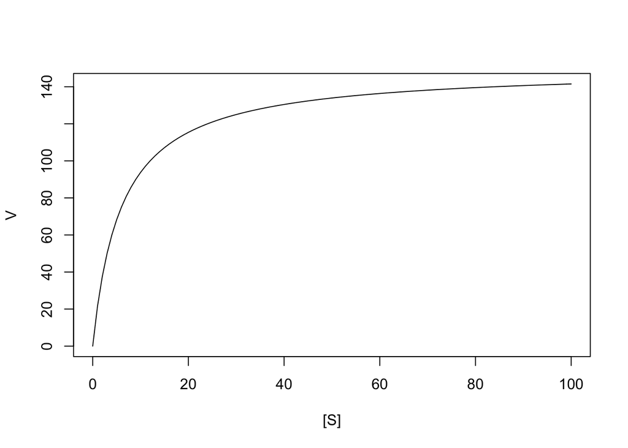

### Reference

Johnson, K. A.and Goody, R. S. (2011). The original Michaelis constant: translation of the 1913 Michaelis–Menten paper. *Biochemistry*, 50(39), 8264-8269.